# Plots for `Voice quality and coda /r/ in Glasgow English in the early 20th century’

This R-markdown file can be used to recreate the plots in our paper titled “Voice quality and coda /r/ in Glasgow English in the early 20th century”. The plots are presented in the same order as they are in the paper, and the section numbering also follows our paper (which means that it actually starts at 4.1, which is the first results section in the paper).

We start by importing all relevant libraries and the data. The details of the data processing (e.g. exclusion of outliers) are shown in a separate file titled *data_prep.Rmd*.

Let’s import the data and relevant libraries first. Note that we have saved our statistical models as RDS files, which allows the user to save time by not having to refit them.

```r
library(lme4)
library(mgcv)
library(itsadug)
library(rms)
library(tidyverse)
library(stringr)
library(effects)
library(here)
library(afex)
# vowel data
vowels <- read_csv("data/vowels.csv")
# formatting for mixed effects models
vowels$Speaker <- as.factor(vowels$Speaker)
vowels$Target.orthography <- as.factor(vowels$Target.orthography)
vowels$vowel <- as.factor(vowels$vowel)
vowels$decade <- ifelse(vowels$decade=="00", 2000, as.numeric(vowels$decade) + 1900)
vowels$decade.fact <- factor(vowels$decade.fact, levels=c("70","80","90","00"))
# /r/ data
R <- read_csv("data/R.csv") # F/M confuse read_csv...
```

```
4554 parsing failures.
 row    col           expected actual         file
1090 gender 1/0/T/F/TRUE/FALSE      M 'data/R.csv'
1091 gender 1/0/T/F/TRUE/FALSE      M 'data/R.csv'
1092 gender 1/0/T/F/TRUE/FALSE      M 'data/R.csv'
1093 gender 1/0/T/F/TRUE/FALSE      M 'data/R.csv'
1094 gender 1/0/T/F/TRUE/FALSE      M 'data/R.csv'
.... ...... .................. ...... ............
See problems(...) for more details.
```

```r
coltyps <- spec(R)
coltyps$cols$gender <- col_character()
# and again!
R <- read_csv("data/R.csv", col_types=coltyps)
```

```
132 parsing failures.
 row     col           expected actual         file
1233 exclude 1/0/T/F/TRUE/FALSE   unex 'data/R.csv'
1234 exclude 1/0/T/F/TRUE/FALSE   unex 'data/R.csv'
1235 exclude 1/0/T/F/TRUE/FALSE   unex 'data/R.csv'
1236 exclude 1/0/T/F/TRUE/FALSE   unex 'data/R.csv'
1237 exclude 1/0/T/F/TRUE/FALSE   unex 'data/R.csv'
.... ....... .................. ...... ............
See problems(...) for more details.
```

```r
# some changes to variables to make them work with GAMMs
R <- R %>%
  mutate(stress = as.ordered(stress),
         start.event = (measurement.no==0),
         foll.broad.f3 = as.factor(foll.broad.f3),
         speaker = as.factor(speaker),
         word = as.factor(word))
contrasts(R$stress) <- "contr.treatment"
# separate data sets for males and females
R.m <- R %>%
  filter(gender=="M")
R.f <- R %>%
  filter(gender=="F")
# setting up variables for analysis via GAMMs
R$trans.broad <- recode(R$trans, wa="a")
R$trans.broad.fact <- as.ordered(R$trans.broad)
contrasts(R$trans.broad.fact) <- "contr.treatment"
R$gender.ordered <- as.ordered(R$gender)
contrasts(R$gender.ordered) <- "contr.treatment"
# auditory R data -- create data set with unique realisations
R.aud <- R[!(R$trans %in% c("", "?r")) & R$measurement.no==0,]
# only a few weakened approximants, so fold these into other categories
R.aud <- R %>%
  filter(!(trans %in% c("", "?r")),
         !is.na(trans),
         measurement.no==0) %>%
  mutate(trans.broad=recode(trans, wa="a"),
         gender=recode(gender, M="male", `F`="female"))
# auditory voice quality data
# getting f3 avgs
avg.f3 <- unique(select(R, speaker, avg.f3))
# reading & formatting data
R.vq <- read_csv("data/auditoryvq.csv") %>%
  rename(speaker="speaker code",
         advanced.tip.blade="advanced tip/blade",
         tongue.body.height="tongue body height",
         tongue.body.front.backness="tongue body front-backness") %>%
  # join with avg.f3!
  inner_join(avg.f3, by="speaker") %>%
  mutate(gender=as.factor(ifelse(!is.na(str_match(speaker, "-m0")), "male", "female")),
         decade=unlist(substr(speaker, 1, 2)),
         decade=as.numeric(recode(decade, `00`="100")) + 1900)
```

```
Column `speaker` joining character vector and factor, coercing into character vector
```

# 4.1: Changes to coda /r/ – Take 1: Acoustic results

## Males without baseline control

Creating figure 2 bottom panel showing the model predictions for males.

```
Predictor decade is not a factor.
```

```
Summary:
    * stress : factor; set to the value(s): full.
    * measurement.no : numeric predictor; with 100 values ranging from 0.000000 to 10.000000.
    * decade : numeric predictor; with 4 values ranging from 1970.000000 to 2000.000000.
    * duration : numeric predictor; set to the value(s): 0.122709575.
    * preceding.front : numeric predictor; set to the value(s): 1.
    * foll.broad.f3 : factor; set to the value(s): labial. (Might be canceled as random effect, check below.)
    * speaker : factor; set to the value(s): 00-O-m06. (Might be canceled as random effect, check below.)
    * word : factor; set to the value(s): were. (Might be canceled as random effect, check below.)
    * NOTE : The following random effects columns are canceled: s(measurement.no,foll.broad.f3),s(measurement.no,speaker),s(measurement.no,word)
```

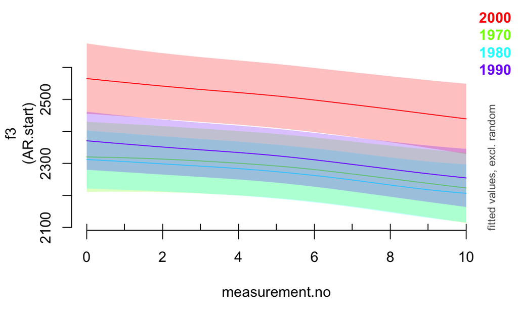

```r
# importing statistical model
R.m.mod.AR <- readRDS("models/R.m.mod.AR")
# extracting model predictions (using plot_smooth from itsadug)
R.m.full.plot <- plot_smooth(R.m.mod.AR, view="measurement.no", plot_all="decade",
            cond=list(stress="full"), rm.ranef=T, n.grid=100)$fv
```

```
Predictor decade is not a factor.
```

```
Summary:
    * stress : factor; set to the value(s): schwa.
    * measurement.no : numeric predictor; with 100 values ranging from 0.000000 to 10.000000.
    * decade : numeric predictor; with 4 values ranging from 1970.000000 to 2000.000000.
    * duration : numeric predictor; set to the value(s): 0.122709575.
    * preceding.front : numeric predictor; set to the value(s): 1.
    * foll.broad.f3 : factor; set to the value(s): labial. (Might be canceled as random effect, check below.)
    * speaker : factor; set to the value(s): 00-O-m06. (Might be canceled as random effect, check below.)
    * word : factor; set to the value(s): were. (Might be canceled as random effect, check below.)
    * NOTE : The following random effects columns are canceled: s(measurement.no,foll.broad.f3),s(measurement.no,speaker),s(measurement.no,word)
```

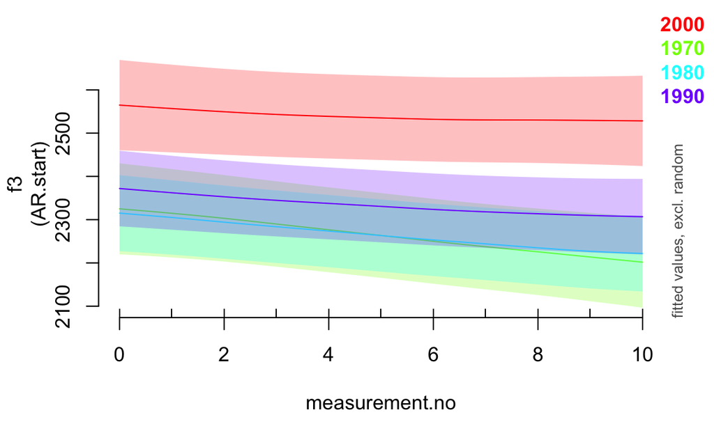

```r
R.m.schwa.plot <- plot_smooth(R.m.mod.AR, view="measurement.no", plot_all="decade",
            cond=list(stress="schwa"), rm.ranef=T, n.grid=100)$fv
```

```
Duplicated aesthetics after name standardisation: colour
```

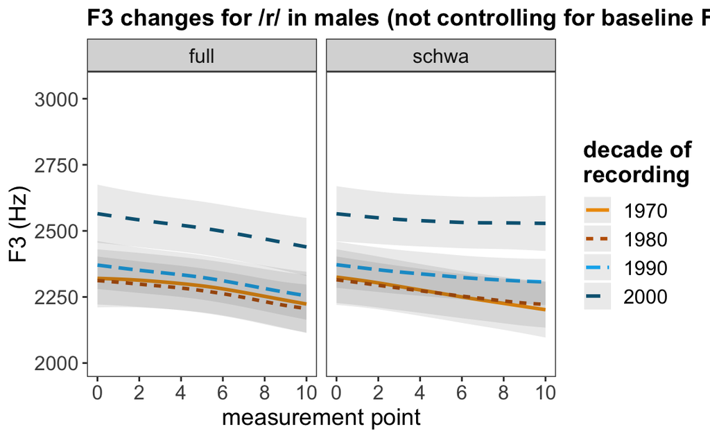

```r
R.m.plot <- rbind(R.m.full.plot, R.m.schwa.plot)
# formatting decade predictor
R.m.plot$decade <- factor(R.m.plot$decade, levels=c("1970","1980","1990","2000"))
# creating the plot
ggplot(R.m.plot, aes(x=measurement.no, y=fit, group=decade, col=decade, lty=decade)) +
  geom_line(lwd=1) +
  facet_grid(.~stress) +
  geom_ribbon(aes(ymin=ll, ymax=ul, group=decade), col=NA,col="grey", alpha=0.1) +
  scale_color_manual(values=c("orange","darkorange3","deepskyblue1","deepskyblue4"),
                     name="decade of\nrecording") +
  scale_linetype_discrete(name="decade of\nrecording") +
  scale_x_continuous(name="measurement point", limits = c(0, 10), breaks=seq(0,10,2)) +
  scale_y_continuous(name="F3 (Hz)", limits=c(2000, 3050)) +
  theme_bw() +
  theme(axis.title = element_text(size=14),
        axis.text = element_text(size=12),
        legend.title = element_text(size=14, face="bold"),
        legend.text=element_text(size=12),
        plot.title=element_text(size=14, face="bold"),
        panel.grid=element_blank(),
        strip.text=element_text(size=12)) +
  ggtitle("F3 changes for /r/ in males (not controlling for baseline F3)")
```

```r
#ggsave("graphs/r_male_f3_change_no_control.pdf", width=8, height=4)
```

## Females without baseline control

Creating figure 2 top panel showing the model predictions for females.

```
Predictor decade is not a factor.
```

```
Summary:
    * stress : factor; set to the value(s): full.
    * measurement.no : numeric predictor; with 100 values ranging from 0.000000 to 10.000000.
    * decade : numeric predictor; with 4 values ranging from 1970.000000 to 2000.000000.
    * duration : numeric predictor; set to the value(s): 0.103923377.
    * preceding.front : numeric predictor; set to the value(s): 1.
    * foll.broad.f3 : factor; set to the value(s): coronal. (Might be canceled as random effect, check below.)
    * speaker : factor; set to the value(s): 00-O-f01. (Might be canceled as random effect, check below.)
    * word : factor; set to the value(s): were. (Might be canceled as random effect, check below.)
    * NOTE : The following random effects columns are canceled: s(measurement.no,foll.broad.f3),s(measurement.no,speaker),s(measurement.no,word)
```

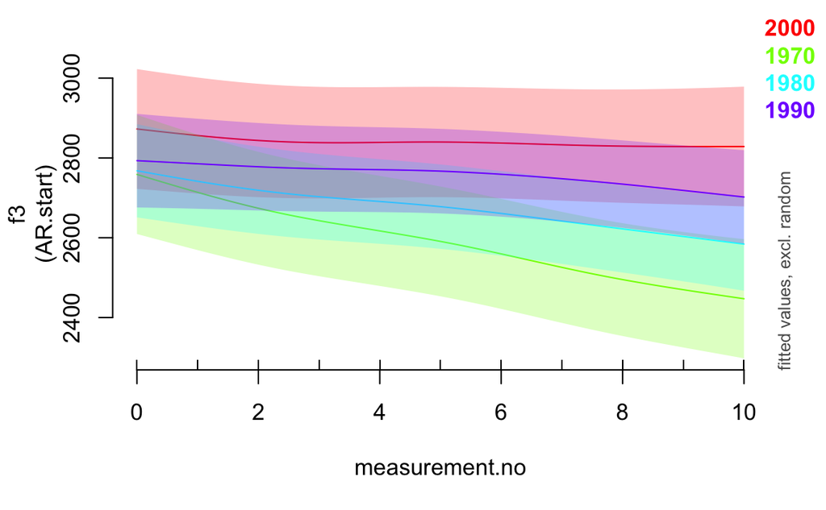

```r
# importing statistical model
R.f.mod.AR <- readRDS("models/R.f.mod.AR")
# extracting model predictions (using plot_smooth from itsadug)
R.f.full.plot <- plot_smooth(R.f.mod.AR, view="measurement.no", plot_all="decade",
            cond=list(stress="full"), rm.ranef=T, n.grid=100)$fv
```

```
Predictor decade is not a factor.
```

```
Summary:
    * stress : factor; set to the value(s): schwa.
    * measurement.no : numeric predictor; with 100 values ranging from 0.000000 to 10.000000.
    * decade : numeric predictor; with 4 values ranging from 1970.000000 to 2000.000000.
    * duration : numeric predictor; set to the value(s): 0.103923377.
    * preceding.front : numeric predictor; set to the value(s): 1.
    * foll.broad.f3 : factor; set to the value(s): coronal. (Might be canceled as random effect, check below.)
    * speaker : factor; set to the value(s): 00-O-f01. (Might be canceled as random effect, check below.)
    * word : factor; set to the value(s): were. (Might be canceled as random effect, check below.)
    * NOTE : The following random effects columns are canceled: s(measurement.no,foll.broad.f3),s(measurement.no,speaker),s(measurement.no,word)
```

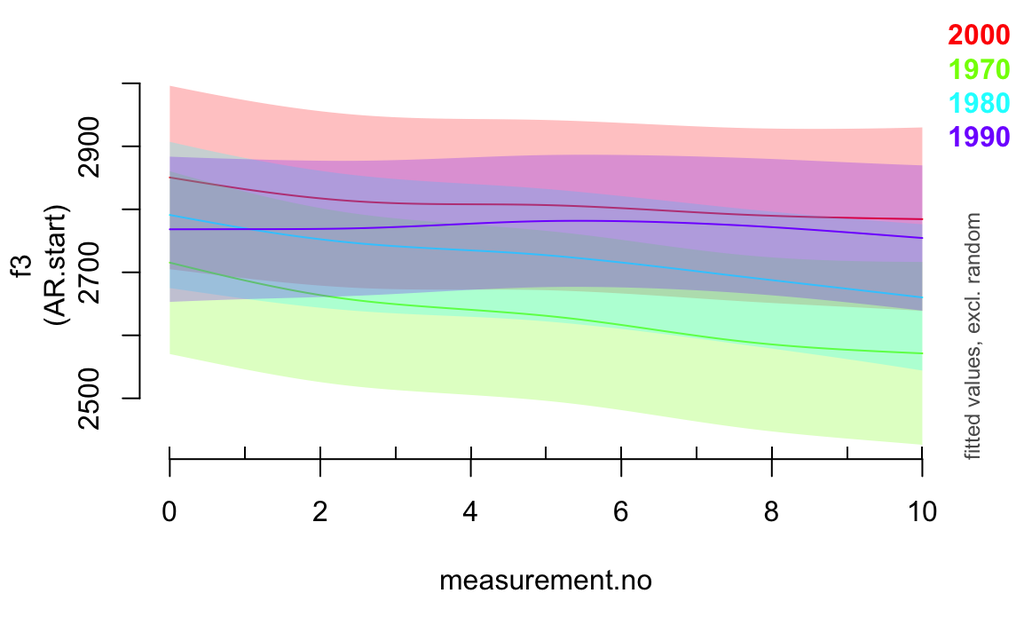

```r
R.f.schwa.plot <- plot_smooth(R.f.mod.AR, view="measurement.no", plot_all="decade",
            cond=list(stress="schwa"), rm.ranef=T, n.grid=100)$fv
```

```
Duplicated aesthetics after name standardisation: colour
```

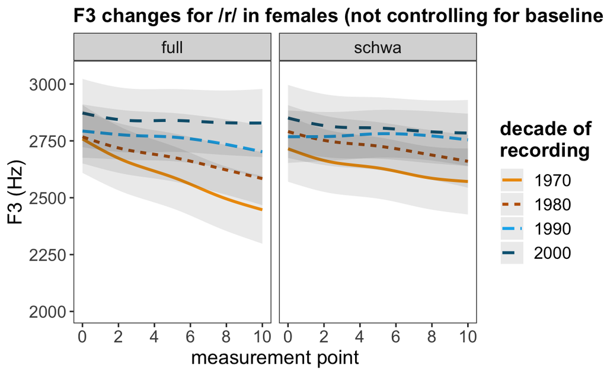

```r
R.f.plot <- rbind(R.f.full.plot, R.f.schwa.plot)
# formatting decade predictor
R.f.plot$decade <- factor(R.f.plot$decade, levels=c("1970","1980","1990","2000"))

# creating plot
ggplot(R.f.plot, aes(x=measurement.no, y=fit, group=decade, col=decade, lty=decade)) +
  geom_line(lwd=1) +
  facet_grid(.~stress) +
  geom_ribbon(aes(ymin=ll, ymax=ul, group=decade), col=NA,col="grey", alpha=0.1) +
  scale_color_manual(name="decade of\nrecording", values=c("orange","darkorange3","deepskyblue1","deepskyblue4")) +
  scale_linetype_discrete(name="decade of\nrecording") +
  scale_x_continuous(name="measurement point", limits = c(0, 10), breaks=seq(0,10,2)) +
  scale_y_continuous(name="F3 (Hz)", limits=c(2000, 3050)) +
  theme_bw() +
  theme(axis.title = element_text(size=14),
        axis.text = element_text(size=12),
        legend.title = element_text(size=14, face="bold"),
        legend.text=element_text(size=12),
        plot.title=element_text(size=14, face="bold"),
        panel.grid=element_blank(),
        strip.text=element_text(size=12)) +
  ggtitle("F3 changes for /r/ in females (not controlling for baseline F3)")
```

```r
#ggsave("graphs/r_female_f3_change_no_control.pdf", width=8, height=4)
```

# 4.2: Changes to coda /r/ – Take 1: Auditory results

Creating figure 3.

```
Summary:
    * stress : factor; set to the value(s): schwa.
    * trans.broad.fact : factor; set to the value(s): a, i, o, r, t, wt.
    * gender : factor; set to the value(s): F.
    * measurement.no : numeric predictor; with 30 values ranging from 0.000000 to 10.000000.
    * duration : numeric predictor; set to the value(s): 0.11452771.
    * preceding.front : numeric predictor; set to the value(s): 1.
    * foll.broad.f3 : factor; set to the value(s): labial. (Might be canceled as random effect, check below.)
    * speaker : factor; set to the value(s): 00-O-f01. (Might be canceled as random effect, check below.)
    * word : factor; set to the value(s): were. (Might be canceled as random effect, check below.)
    * NOTE : The following random effects columns are canceled: s(measurement.no,foll.broad.f3),s(measurement.no,speaker),s(measurement.no,word)
```

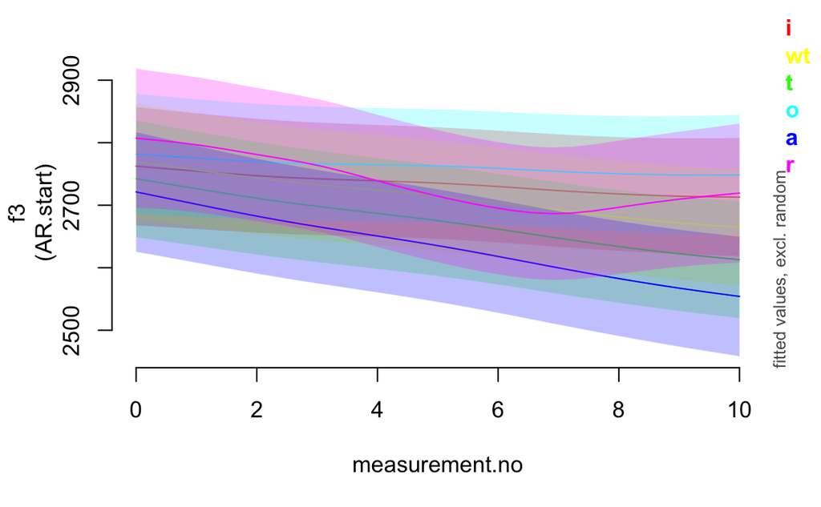

```r
# importing model
R.shapes.mod.AR <- readRDS("models/R.shapes.mod.AR")
# extracting model predictions
R.shapes <- plot_smooth(R.shapes.mod.AR, view="measurement.no", plot_all="trans.broad.fact",
                        cond=list(gender="F"), rm.ranef=T, rug=F)[[1]]
```

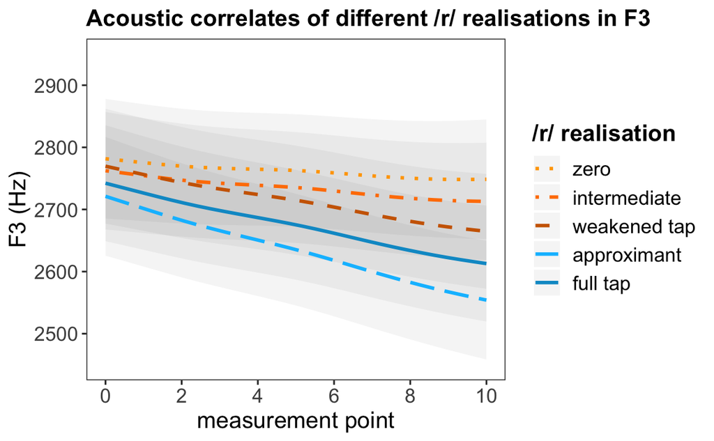

```r
# releveling, meaningful names for realisations
R.shapes$trans.broad.fact <- factor(R.shapes$trans.broad.fact, levels=c("o","i","wt","a","t","r"))
R.shapes <- R.shapes %>%
  mutate(realisation=recode(trans.broad.fact,
                            o="zero",
                            i="intermediate",
                            wt="weakened tap",
                            a="approximant",
                            t="full tap",
                            r="trill"),
         realisation=factor(realisation,
                            levels=c("zero",
                                     "intermediate",
                                     "weakened tap",
                                     "approximant",
                                     "full tap",
                                     "trill"))
  )
# excluding trills
R.shapes <- filter(R.shapes, trans.broad.fact != "r")
# creating graph
ggplot(R.shapes, aes(x=measurement.no, y=fit, col=realisation, lty=realisation)) +
  geom_ribbon(aes(ymin=ll, ymax=ul, group=trans.broad.fact), alpha=0.05, colour=NA) +
  geom_line(lwd=1) +
  scale_linetype_manual(values = c(3,4,2,
                              5,1),
                     name="/r/ realisation") +
  scale_colour_manual(values = c("orange","darkorange1",
                               "darkorange3","deepskyblue1",
                               "deepskyblue3"),
                      name="/r/ realisation") +
  scale_x_continuous(name="measurement point", limits = c(0, 10), breaks=seq(0,10,2)) +
  scale_y_continuous(name="F3 (Hz)", limits=c(2450,2950)) +
  theme_bw() +
  theme(axis.title = element_text(size=14),
        axis.text = element_text(size=12),
        legend.title = element_text(size=14, face="bold"),
        legend.text=element_text(size=12),
        plot.title=element_text(size=14, face="bold"),
        panel.grid=element_blank(),
        strip.text=element_text(size=12)) +
  ggtitle("Acoustic correlates of different /r/ realisations in F3")
```

```r
#ggsave("graphs/r_acoustic_correlates.pdf", width=6, height=4)
```

We now create figure 4, that is, the proportions of different realisations as a function of time.

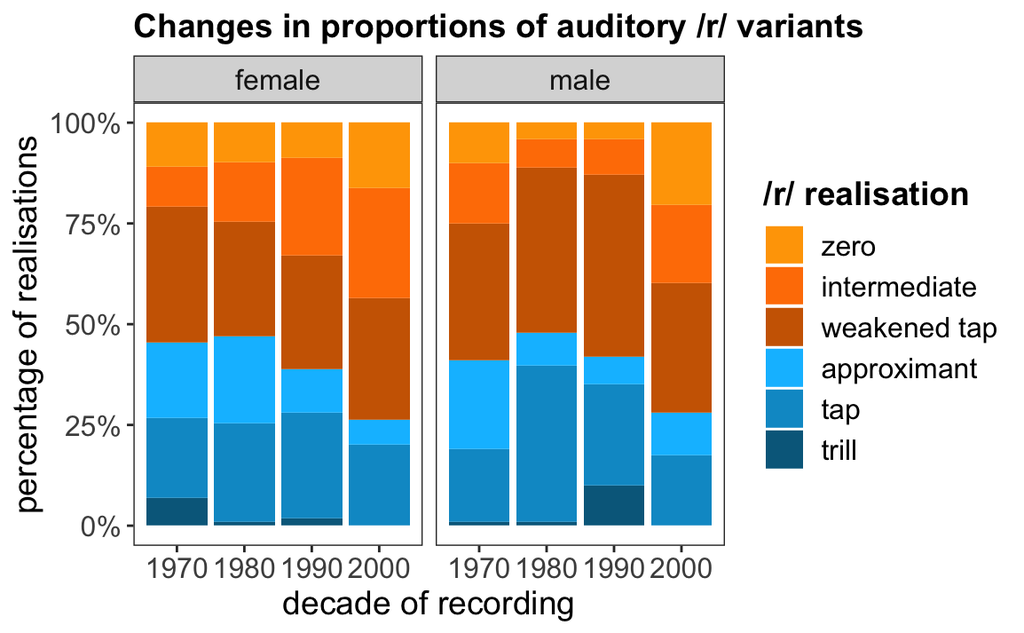

```r
# calculating proportions
R.props.dec <- R.aud %>%
  count(decade, gender, trans.broad) %>%
  group_by(decade, gender) %>%
  mutate(prop = n/sum(n)) %>%
  ungroup()
# releveling
R.props.dec$trans.broad <- factor(R.props.dec$trans.broad, levels=c("o","i","wt","a","t","r"))
# creating the graph
ggplot(R.props.dec, aes(x=decade, fill=trans.broad)) +
  geom_bar(aes(y=prop), stat="identity", position="stack") +
  facet_wrap(~gender) +
  scale_fill_manual(values = c("orange","darkorange1",
                               "darkorange3","deepskyblue1",
                               "deepskyblue3","deepskyblue4"),
                     name="/r/ realisation",
                    labels=c("zero","intermediate",
                             "weakened tap","approximant",
                             "tap","trill")) +
  scale_y_continuous(labels = scales::percent, name="percentage of realisations") +
  scale_x_continuous(name = "decade of recording") +
  theme_bw() +
  theme(axis.title = element_text(size=14),
        axis.text = element_text(size=12),
        legend.title = element_text(size=14, face="bold"),
        legend.text=element_text(size=12),
        plot.title=element_text(size=14, face="bold"),
        panel.grid=element_blank(),
        strip.text=element_text(size=12)) +
ggtitle("Changes in proportions of auditory /r/ variants")
```

```r
#ggsave("graphs/r_auditory.pdf", width=8, height=4)
```

# 5.1 Acoustic results for voice quality

Prediction plot for the paper, i.e. figure 5:

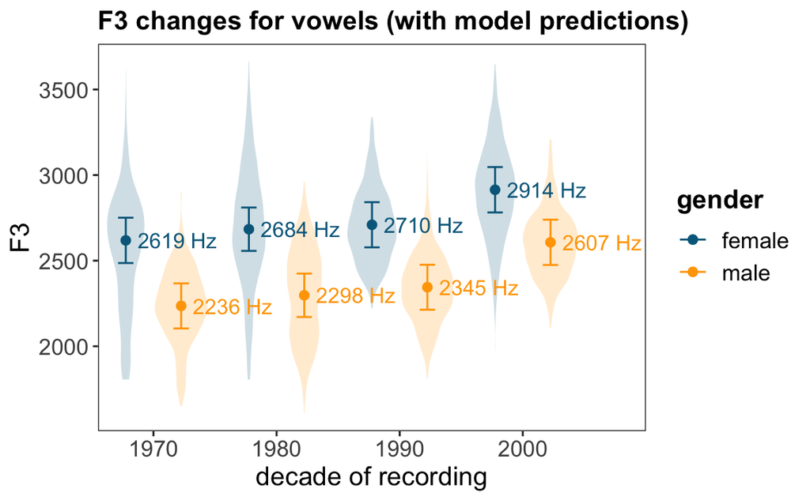

```r
f3.mod.full <- readRDS("models/f3.mod.full")
# extracting predictions from the model
new.dat <- expand.grid(gender=unique(vowels$gender),
                       decade.fact=levels(vowels$decade.fact),
                       duration=median(vowels$duration),
                       vowel=unique(vowels$vowel)[1])
new.dat$f3 <- 0
new.dat$f3 <- predict(f3.mod.full, new.dat, re.form=NA)
mm <- model.matrix(terms(f3.mod.full),new.dat) # for confidence intervals
pvar1 <- diag(mm %*% tcrossprod(vcov(f3.mod.full),mm))
new.dat <- data.frame(
    new.dat,
    lower = new.dat$f3-2*sqrt(pvar1),
    upper = new.dat$f3+2*sqrt(pvar1)
)
# creating the graph
mean_fun <- function(x){
  return(data.frame(y = mean(x), label = paste0("  ", round(mean(x)), " Hz")))
}
ggplot(new.dat, aes(x=decade.fact, y=f3, col=gender)) +
  geom_violin(data=vowels, aes(fill=gender, col=NA), alpha=0.2, show.legend=F) +
  geom_point(size=2, position=position_dodge(width=0.9)) +
  geom_errorbar(aes(ymin=lower, ymax=upper), width=0.25, position=position_dodge(width=0.9)) +
  stat_summary(fun.data = mean_fun, geom = "text", size=4, position=position_dodge(0.9), hjust=0, show.legend=F) +
  scale_color_manual(name="gender",breaks=c("F","M"), labels=c("female", "male"),
                     values=c("deepskyblue4","orange")) +
  scale_fill_manual(name="gender",breaks=c("F","M"), labels=c("female", "male"),
                     values=c("deepskyblue4","orange"), guide=F) +
  scale_x_discrete(name="decade of recording", labels=c(1970,1980,1990,2000), expand=expand_scale(add=c(0.05,1))) +
  scale_y_continuous(name="F3") +
  theme_bw() +
  theme(axis.title = element_text(size=14),
        axis.text = element_text(size=12),
        legend.title = element_text(size=14, face="bold"),
        legend.text=element_text(size=12),
        plot.title=element_text(size=14, face="bold"),
        panel.grid=element_blank()) +
  ggtitle("F3 changes for vowels (with model predictions)")
```

```r
#ggsave("graphs/vowels_f3_change.pdf", width=8, height=4)
```

# 5.2 Auditory results for voice quality

Create figure 6.

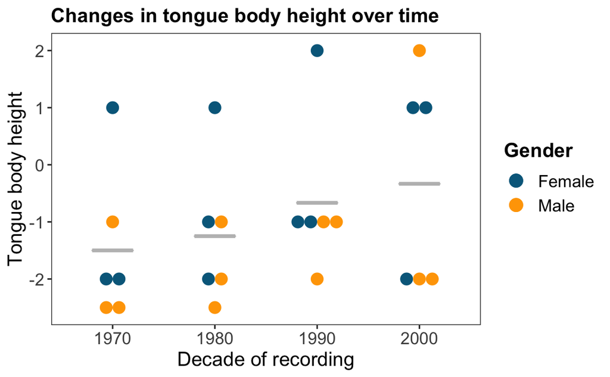

```r
# getting counts of different tongue body height values per decade
R.vq.count <- dplyr::count(R.vq, tongue.body.height, decade)
# arranging by decade / tongue body height
R.vq.ordered <- R.vq %>%
  arrange(decade, tongue.body.height)
# creating graph
ggplot(R.vq.ordered, aes(x=factor(decade), y=tongue.body.height)) +
  geom_point(x=1,y=1, aes(colour="Female")) + # this is a hack for getting the legend right
  geom_point(x=1,y=1, aes(colour="Male")) + # this is a hack for getting the legend right
  scale_color_manual(name="Gender", values=c("deepskyblue4","orange"), breaks=c("Female","Male")) +
  geom_dotplot(binaxis="y", stackdir="center", binpositions="all",
               fill=ifelse(R.vq.ordered$gender=="female", "deepskyblue4","orange"),
               col=NA, dotsize=1.5) +
  stat_summary(fun.y=mean, fun.ymin=mean, fun.ymax=mean, geom="crossbar", aes(group=decade), width=0.4, col="grey") +
  scale_x_discrete(name="Decade of recording") +
  scale_y_continuous(name="Tongue body height") +
  guides(colour = guide_legend(override.aes = list(size = 4))) +
  theme_bw() +
  theme(axis.title = element_text(size=14),
        axis.text = element_text(size=12),
        legend.title = element_text(size=14, face="bold"),
        legend.text=element_text(size=12),
        plot.title=element_text(size=14, face="bold"),
        panel.grid=element_blank(),
        strip.text=element_text(size=12)) +
  ggtitle("Changes in tongue body height over time")
```

```r
# ggsave("graphs/tongue_body_height.pdf", width=6, height=4)
```

# Changes to Coda R: take 2 – acoustic analysis

## Males, take 2 (with baseline control)

Creating the bottom panel of figure 7.

```
Predictor decade is not a factor.
```

```
Summary:
    * stress : factor; set to the value(s): full.
    * avg.f3 : numeric predictor; set to the value(s): 2405.03714710253.
    * measurement.no : numeric predictor; with 100 values ranging from 0.000000 to 10.000000.
    * decade : numeric predictor; with 4 values ranging from 1970.000000 to 2000.000000.
    * duration : numeric predictor; set to the value(s): 0.122709575.
    * preceding.front : numeric predictor; set to the value(s): 1.
    * foll.broad.f3 : factor; set to the value(s): labial. (Might be canceled as random effect, check below.)
    * speaker : factor; set to the value(s): 00-O-m06. (Might be canceled as random effect, check below.)
    * word : factor; set to the value(s): were. (Might be canceled as random effect, check below.)
    * NOTE : The following random effects columns are canceled: s(measurement.no,foll.broad.f3),s(measurement.no,speaker),s(measurement.no,word)
```

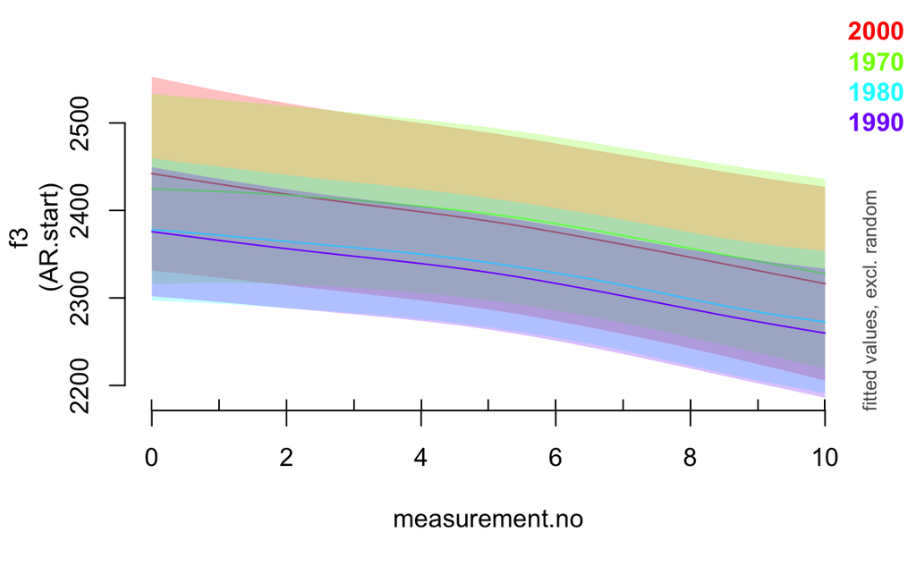

```r
# importing model
R.m.baseline.mod.AR <- readRDS("models/R.m.baseline.mod.AR")
# extracting predictions, formatting decade
R.m.baseline.full.plot <- plot_smooth(R.m.baseline.mod.AR, view="measurement.no", plot_all="decade",
            cond=list(stress="full"), rm.ranef=T, n.grid=100)$fv
```

```
Predictor decade is not a factor.
```

```
Summary:
    * stress : factor; set to the value(s): schwa.
    * avg.f3 : numeric predictor; set to the value(s): 2405.03714710253.
    * measurement.no : numeric predictor; with 100 values ranging from 0.000000 to 10.000000.
    * decade : numeric predictor; with 4 values ranging from 1970.000000 to 2000.000000.
    * duration : numeric predictor; set to the value(s): 0.122709575.
    * preceding.front : numeric predictor; set to the value(s): 1.
    * foll.broad.f3 : factor; set to the value(s): labial. (Might be canceled as random effect, check below.)
    * speaker : factor; set to the value(s): 00-O-m06. (Might be canceled as random effect, check below.)
    * word : factor; set to the value(s): were. (Might be canceled as random effect, check below.)
    * NOTE : The following random effects columns are canceled: s(measurement.no,foll.broad.f3),s(measurement.no,speaker),s(measurement.no,word)
```

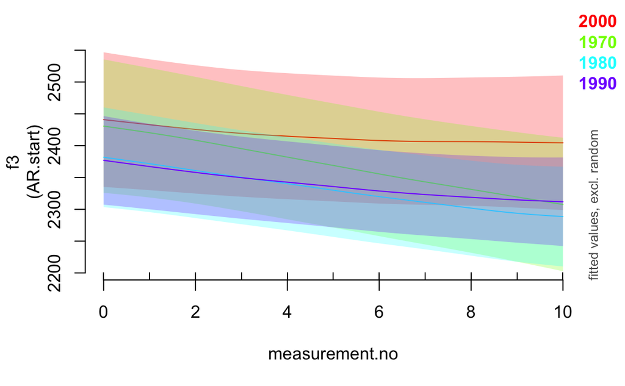

```r
R.m.baseline.schwa.plot <- plot_smooth(R.m.baseline.mod.AR, view="measurement.no", plot_all="decade",
            cond=list(stress="schwa"), rm.ranef=T, n.grid=100)$fv
```

```
Duplicated aesthetics after name standardisation: colour
```

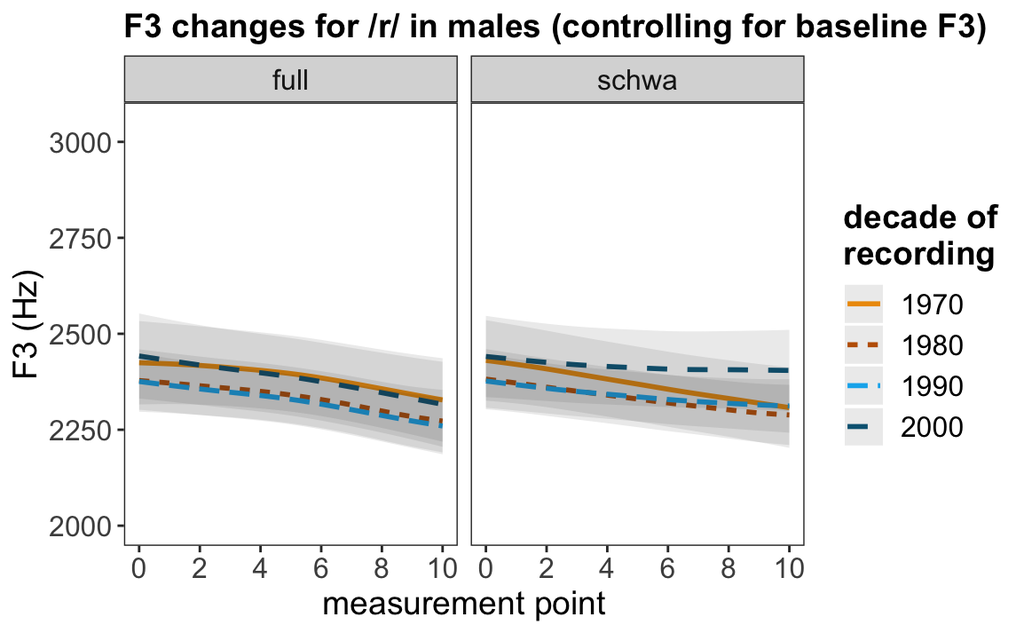

```r
R.m.baseline.plot <- rbind(R.m.baseline.full.plot, R.m.baseline.schwa.plot)
R.m.baseline.plot$decade <- factor(R.m.baseline.plot$decade, levels=c("1970","1980","1990","2000"))
# create graph
ggplot(R.m.baseline.plot, aes(x=measurement.no, y=fit, group=decade, col=decade, lty=decade)) +
  geom_line(lwd=1) +
  facet_grid(.~stress) +
  geom_ribbon(aes(ymin=ll, ymax=ul, group=decade), col=NA,col="grey", alpha=0.1) +
  scale_color_manual(name="decade of\nrecording", values=c("orange","darkorange3","deepskyblue1","deepskyblue4")) +
  scale_linetype_discrete(name="decade of\nrecording") +
  scale_x_continuous(name="measurement point", limits = c(0, 10), breaks=seq(0,10,2)) +
  scale_y_continuous(name="F3 (Hz)", limits=c(2000, 3050)) +
  theme_bw() +
  theme(axis.title = element_text(size=14),
        axis.text = element_text(size=12),
        legend.title = element_text(size=14, face="bold"),
        legend.text=element_text(size=12),
        plot.title=element_text(size=14, face="bold"),
        panel.grid=element_blank(),
        strip.text=element_text(size=12)) +
  ggtitle("F3 changes for /r/ in males (controlling for baseline F3)")
```

```r
#ggsave("graphs/r_male_f3_change_control.pdf", width=8, height=4)
```

## Females, take 2 (with baseline control)

Creating the top panel of figure 7.

```
Predictor decade is not a factor.
```

```
Summary:
    * stress : factor; set to the value(s): full.
    * avg.f3 : numeric predictor; set to the value(s): 2717.01597051597.
    * measurement.no : numeric predictor; with 100 values ranging from 0.000000 to 10.000000.
    * decade : numeric predictor; with 4 values ranging from 1970.000000 to 2000.000000.
    * duration : numeric predictor; set to the value(s): 0.103923377.
    * preceding.front : numeric predictor; set to the value(s): 1.
    * foll.broad.f3 : factor; set to the value(s): coronal. (Might be canceled as random effect, check below.)
    * speaker : factor; set to the value(s): 00-O-f01. (Might be canceled as random effect, check below.)
    * word : factor; set to the value(s): were. (Might be canceled as random effect, check below.)
    * NOTE : The following random effects columns are canceled: s(measurement.no,foll.broad.f3),s(measurement.no,speaker),s(measurement.no,word)
```

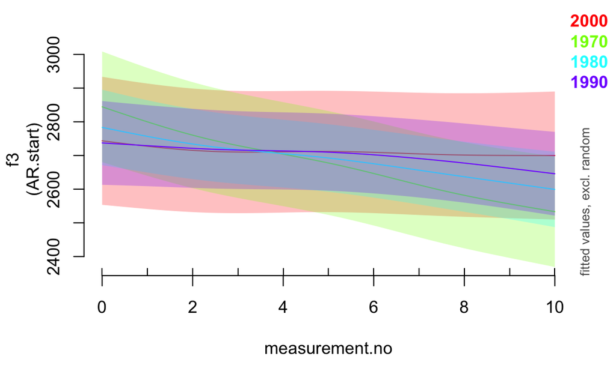

```r
# importing model
R.f.baseline.mod.AR <- readRDS("models/R.f.baseline.mod.AR")
# extracting predictions, formatting decades
R.f.baseline.full.plot <- plot_smooth(R.f.baseline.mod.AR, view="measurement.no", plot_all="decade",
            cond=list(stress="full"), rm.ranef=T, n.grid=100)$fv
```

```
Predictor decade is not a factor.
```

```
Summary:
    * stress : factor; set to the value(s): schwa.
    * avg.f3 : numeric predictor; set to the value(s): 2717.01597051597.
    * measurement.no : numeric predictor; with 100 values ranging from 0.000000 to 10.000000.
    * decade : numeric predictor; with 4 values ranging from 1970.000000 to 2000.000000.
    * duration : numeric predictor; set to the value(s): 0.103923377.
    * preceding.front : numeric predictor; set to the value(s): 1.
    * foll.broad.f3 : factor; set to the value(s): coronal. (Might be canceled as random effect, check below.)
    * speaker : factor; set to the value(s): 00-O-f01. (Might be canceled as random effect, check below.)
    * word : factor; set to the value(s): were. (Might be canceled as random effect, check below.)
    * NOTE : The following random effects columns are canceled: s(measurement.no,foll.broad.f3),s(measurement.no,speaker),s(measurement.no,word)
```

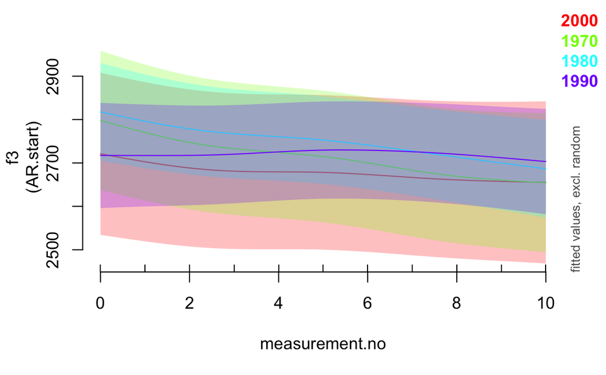

```r
R.f.baseline.schwa.plot <- plot_smooth(R.f.baseline.mod.AR, view="measurement.no", plot_all="decade",
            cond=list(stress="schwa"), rm.ranef=T, n.grid=100)$fv
```

```
Duplicated aesthetics after name standardisation: colour
```

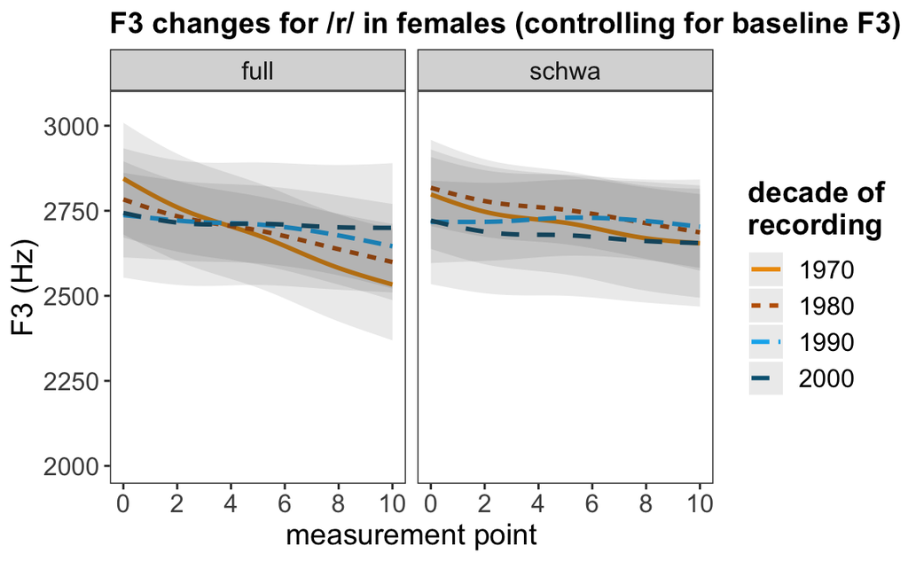

```r
R.f.baseline.plot <- rbind(R.f.baseline.full.plot, R.f.baseline.schwa.plot)
R.f.baseline.plot$decade <- factor(R.f.baseline.plot$decade, levels=c("1970","1980","1990","2000"))
# creating graph
ggplot(R.f.baseline.plot, aes(x=measurement.no, y=fit, group=decade, col=decade, lty=decade)) +
  geom_line(lwd=1) +
  facet_grid(.~stress) +
  geom_ribbon(aes(ymin=ll, ymax=ul, group=decade), col=NA,col="grey", alpha=0.1) +
  scale_color_manual(name="decade of\nrecording", values=c("orange","darkorange3","deepskyblue1","deepskyblue4")) +
  scale_linetype_discrete(name="decade of\nrecording") +
  scale_x_continuous(name="measurement point", limits = c(0, 10), breaks=seq(0,10,2)) +
  scale_y_continuous(name="F3 (Hz)", limits=c(2000, 3050)) +
  theme_bw() +
  theme(axis.title = element_text(size=14),
        axis.text = element_text(size=12),
        legend.title = element_text(size=14, face="bold"),
        legend.text=element_text(size=12),
        plot.title=element_text(size=14, face="bold"),
        panel.grid=element_blank(),
        strip.text=element_text(size=12)) +
  ggtitle("F3 changes for /r/ in females (controlling for baseline F3)")
```

```r
#ggsave("graphs/r_female_f3_change_control.pdf", width=8, height=4)
```